# TCGA BRCA Data Exploration

## Setup

```r
synLogin()
```

[output not shown]

## Data collection

### Clinical data

I’ll grab TCGA clinical data from the PanCancer Atlas space in the Genomic Data Commons (GDC). **Note:** I manually downloaded the “GDC Manifest File” from [this page](https://gdc.cancer.gov/about-data/publications/pancanatlas).

```r
# load TCGA PanCanAtlas manifest for GDC
manifest_df <- read_tsv("../data/PanCan-General_Open_GDC-Manifest_0.txt")
```

The TCGA-Clinical Data Resource (CDR) Outcomes is a “curated resource of the clinical annotations for TCGA data and provides recommendations for use of clinical endpoints.” According to the PanCanAtlas page in GDC, “it is strongly recommended that this file be used for clinical elements and survival outcome data first.”

I’ll subset the data to only include samples from breast cancer (BRCA) studies. To reduce the amount of extraneous information, I’ll also remove any variables that are `"Not Applicable"` or `"Not Available"` in more than 25% of BRCA samples.

```r
brca_cdr_clinical_df <- readxl::read_excel(tcga_cdr_clinical_file) %>%
  filter(type == "BRCA") %>%
  select(-X__1)
sparse_vars <- brca_cdr_clinical_df %>%
  summarise_all(.funs = funs(sum(str_detect(., "^\\[Not A.*") | is.na(.)))) %>%
  gather(variable, n_uninformative) %>%
  dplyr::filter(n_uninformative > (nrow(brca_cdr_clinical_df) * 0.25)) %>%
  pluck("variable")
brca_cdr_clinical_df <- select(brca_cdr_clinical_df, -one_of(sparse_vars))
```

Here’s a glimpse of the information included in `brca_cdr_clinical_df`:

```r
summary(brca_cdr_clinical_df)
```

```
 bcr_patient_barcode     type           age_at_initial_pathologic_diagnosis    gender              race
 Length:1097         Length:1097        Min.   :26.00                       Length:1097        Length:1097
 Class :character    Class :character   1st Qu.:49.00                       Class :character   Class :character
 Mode  :character    Mode  :character   Median :58.00                       Mode  :character   Mode  :character
                                        Mean   :58.45
                                        3rd Qu.:67.00
                                        Max.   :90.00
                                        NA's   :1
 ajcc_pathologic_tumor_stage histological_type  initial_pathologic_dx_year menopause_status   birth_days_to
 Length:1097                 Length:1097        Min.   :1988               Length:1097        Min.   :-32873
 Class :character            Class :character   1st Qu.:2007               Class :character   1st Qu.:-24850
 Mode  :character            Mode  :character   Median :2009               Mode  :character   Median :-21559
                                                Mean   :2008                                  Mean   :-21582
                                                3rd Qu.:2010                                  3rd Qu.:-18025
                                                Max.   :2013                                  Max.   : -9706
                                                NA's   :3                                     NA's   :16
 vital_status       tumor_status       last_contact_days_to margin_status            OS            OS.time
 Length:1097        Length:1097        Min.   :  -7         Length:1097        Min.   :0.0000   Min.   :   0
 Class :character   Class :character   1st Qu.: 439         Class :character   1st Qu.:0.0000   1st Qu.: 450
 Mode  :character   Mode  :character   Median : 760         Mode  :character   Median :0.0000   Median : 843
                                       Mean   :1182                            Mean   :0.1376   Mean   :1246
                                       3rd Qu.:1572                            3rd Qu.:0.0000   3rd Qu.:1682
                                       Max.   :8605                            Max.   :1.0000   Max.   :8605
                                       NA's   :152                                              NA's   :1
      DSS             DSS.time         DFI             DFI.time           PFI            PFI.time
 Min.   :0.00000   Min.   :   0   Min.   :0.00000   Min.   :   0.0   Min.   :0.0000   Min.   :   0
 1st Qu.:0.00000   1st Qu.: 450   1st Qu.:0.00000   1st Qu.: 438.5   1st Qu.:0.0000   1st Qu.: 431
 Median :0.00000   Median : 843   Median :0.00000   Median : 763.5   Median :0.0000   Median : 773
 Mean   :0.07699   Mean   :1246   Mean   :0.08814   Mean   :1159.3   Mean   :0.1322   Mean   :1158
 3rd Qu.:0.00000   3rd Qu.:1682   3rd Qu.:0.00000   3rd Qu.:1563.0   3rd Qu.:0.0000   3rd Qu.:1570
 Max.   :1.00000   Max.   :8605   Max.   :1.00000   Max.   :8556.0   Max.   :1.0000   Max.   :8556
 NA's   :19        NA's   :1      NA's   :144       NA's   :145                       NA's   :1
```

Unfortunately not much that obviously relates to metastasis. Per discussions with other members of the mini-DREAM planning committee, it sounds like “TMN Stage” might be a more relevant variable — and this is included in the “Clinical with Follow-up” TCGA PanCanAtlas data:

Applying the same sample and variable subsetting as above…

```r
brca_clinical_df <- read_tsv(tcga_clinical_file, progress = FALSE) %>%
  filter(acronym == "BRCA")
sparse_vars <- brca_clinical_df %>%
  summarise_all(.funs = funs(sum(str_detect(., "^\\[Not A.*") | is.na(.)))) %>%
  gather(variable, n_uninformative) %>%
  dplyr::filter(n_uninformative > (nrow(brca_clinical_df) * 0.25)) %>%
  pluck("variable")
brca_clinical_df <- select(brca_clinical_df, -one_of(sparse_vars))
```

There’s a bit more information here (45) variables), including `pathologic_M` and `pathologic_N` designations for TMN stage.

```r
summary(brca_clinical_df)
```

```
 bcr_patient_uuid   bcr_patient_barcode   acronym             gender          vital_status       days_to_birth
 Length:1099        Length:1099         Length:1099        Length:1099        Length:1099        Length:1099
 Class :character   Class :character    Class :character   Class :character   Class :character   Class :character
 Mode  :character   Mode  :character    Mode  :character   Mode  :character   Mode  :character   Mode  :character



 days_to_last_followup days_to_initial_pathologic_diagnosis age_at_initial_pathologic_diagnosis    icd_10
 Length:1099           Min.   :0                            Min.   :26.00                       Length:1099
 Class :character      1st Qu.:0                            1st Qu.:49.00                       Class :character
 Mode  :character      Median :0                            Median :58.00                       Mode  :character
                       Mean   :0                            Mean   :58.43
                       3rd Qu.:0                            3rd Qu.:67.00
                       Max.   :0                            Max.   :90.00
 tissue_retrospective_collection_indicator icd_o_3_histology  tissue_prospective_collection_indicator
 Length:1099                               Length:1099        Length:1099
 Class :character                          Class :character   Class :character
 Mode  :character                          Mode  :character   Mode  :character



 history_of_neoadjuvant_treatment icd_o_3_site       tumor_tissue_site  new_tumor_event_after_initial_treatment
 Length:1099                      Length:1099        Length:1099        Length:1099
 Class :character                 Class :character   Class :character   Class :character
 Mode  :character                 Mode  :character   Mode  :character   Mode  :character



 radiation_therapy      race             prior_dx          ethnicity         informed_consent_verified
 Length:1099        Length:1099        Length:1099        Length:1099        Length:1099
 Class :character   Class :character   Class :character   Class :character   Class :character
 Mode  :character   Mode  :character   Mode  :character   Mode  :character   Mode  :character



 person_neoplasm_cancer_status  patient_id        year_of_initial_pathologic_diagnosis histological_type
 Length:1099                   Length:1099        Length:1099                          Length:1099
 Class :character              Class :character   Class :character                     Class :character
 Mode  :character              Mode  :character   Mode  :character                     Mode  :character

```

[output cut: 26 more lines]

```
 Mode  :character                         Mode  :character



 breast_carcinoma_estrogen_receptor_status lab_proc_her2_neu_immunohistochemistry_receptor_status
 Length:1099                               Length:1099
 Class :character                          Class :character
 Mode  :character                          Mode  :character



 lab_procedure_her2_neu_in_situ_hybrid_outcome_type
 Length:1099
 Class :character
 Mode  :character
```

It might be worth joining these two tables into one… but I’ll keep them separate for now.

### Expression data

The same expression data is available through both GDC and Synapse. From experience, I’ve found that downloading the data from Synapse is quite a bit faster, so I’ll use that. Here’s where the data can be found:

- **Batch effects normalized mRNA data:** `syn4976363`
- `syn4976369` (`"EB++AdjustPANCAN_IlluminaHiSeq_RNASeqV2.geneExp.tsv"`)

**Note:** I’ll use the `annotables` package to augment the provided Entrez gene IDs with some additional field to provide more context:

- `ensgene` (which I’ll rename to `gene_id` to match the PS-ON data): Ensembl gene ID
- `symbol`: HGNC gene symbol
- `biotype`: Protein coding, pseudogene, mitochondrial tRNA, etc.
- `description`: Full gene name/description

## Data formatting

### Expression data

For the expression data, I’ll just convert the dataframe of normalized values into a matrix and save the file to share (providing an alternative format for anyone who wants to use it). I’ll save normalization and filtering of the data (e.g., log transform, gene filtering), for downstream analysis steps.

#### Save expression matrix file

```r
tcga_brca_expr_norm_mat_file <- "../data/tcga_brca_expr_norm_mat.RData"
if (!fs::file_exists(tcga_brca_expr_norm_mat_file)) {
  brca_expr_norm_mat <- brca_expr_norm_df %>%
    column_to_rownames("gene_id") %>%
    as.matrix()
  save(brca_expr_norm_mat, file = tcga_brca_expr_norm_mat_file)
} else {
  load(tcga_brca_expr_norm_mat_file)
}
```

```
Setting row names on a tibble is deprecated.
```

### Clinical data

I’ll subset the clinical dataframes to match the selection of samples with expression data, then save the results.

```r
brca_clinical_df <- brca_clinical_df %>%
  filter(bcr_patient_barcode %in% names(brca_expr_norm_df))
save(brca_clinical_df, file = "../data/tcga_brca_clinical_df.RData")
brca_cdr_clinical_df <- brca_cdr_clinical_df %>%
  filter(bcr_patient_barcode %in% names(brca_expr_norm_df))
save(brca_cdr_clinical_df, file = "../data/tcga_brca_cdr_clinical_df.RData")
```

## Exploratory data analysis

This is a quick look at the distribution of M- and N-stage designations among BRCA patients (and the overlap between designations).

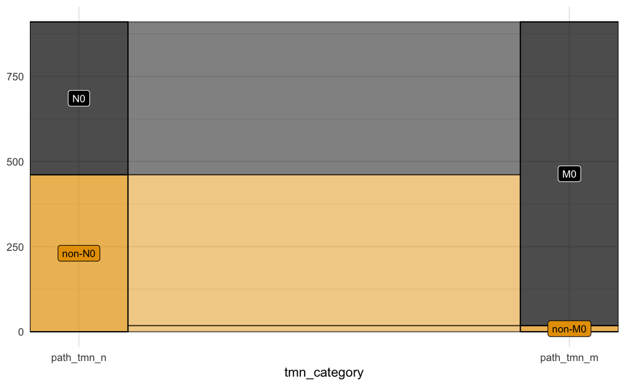

```r
brca_clinical_df %>%
  filter_at(.vars = vars(matches("pathologic_[M|N]")),
            .vars_predicate = all_vars(!str_detect(., "X"))) %>%
  mutate(
    path_tmn_n = if_else(str_detect(pathologic_N, "N0"), "N0", "non-N0"),
    path_tmn_m = if_else(str_detect(pathologic_M, "M0"), "M0", "non-M0")
  ) %>%
  dplyr::select(path_tmn_n, path_tmn_m) %>%
  group_by(path_tmn_n, path_tmn_m) %>%
  tally() %>%
  ungroup() %>%
  rownames_to_column("alluvium") %>%
  gather(tmn_category, tmn_stage, path_tmn_n, path_tmn_m) %>%
  mutate(
    tmn_group = if_else(str_detect(tmn_stage, "non"), "non-0", "0"),
    tmn_category = fct_inorder(tmn_category)
  ) %>%
  ggplot(aes(x = tmn_category, stratum = tmn_stage, alluvium = alluvium,
             weight = n, fill = tmn_group, label = tmn_stage)) +
  geom_flow(colour = "black", width = 1/5) +
  geom_stratum(alpha = 0.7, width = 1/5) +
  geom_label(aes(colour = tmn_group), stat = "stratum", size = 3) +
  scale_x_discrete(expand = c(0, 0)) +
  scale_fill_colorblind() +
  scale_colour_manual(values = c("white", "black")) +
  guides(fill = FALSE, colour = FALSE) +
  theme_minimal()
```